# Plots

Brian Kissmer

2024-09-26

Goals

After working through this handout, you should:

- be more comfortable making plots in `R`

Plots in `R` One of the ways in which `R` really stands out is in its ability to generate plots for visualization. `R` includes many specialized functions for generating specific types of plots, especially when considering plotting functions added by `R` packages and add-on plotting frameworks like `ggplot2`. However, today we will focus on the base `R` plot function, `plot`, which offers considerable versatility and allows us to examine many general aspects of creating plots. This function provides generic x-y plotting capabilities. First, let’s look at the main types of plots the `plot` function generates.

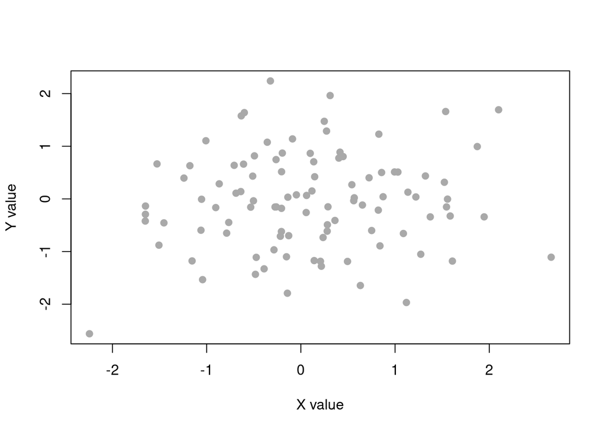

```r
# Simple scatterplot of two variables, x and y
x <- rnorm(100, mean = 0, sd = 1)
y <- rnorm(100, mean = 0, sd = 1)
# xlab and ylab specify the x and y axis labels col specifies the
# color used for the plot For a list of valid colors see
# http://www.stat.columbia.edu/~tzheng/files/Rcolor.pdf
plot(x, y, xlab = "X value", ylab = "Y value", col = "darkgray", pch = 19)
```

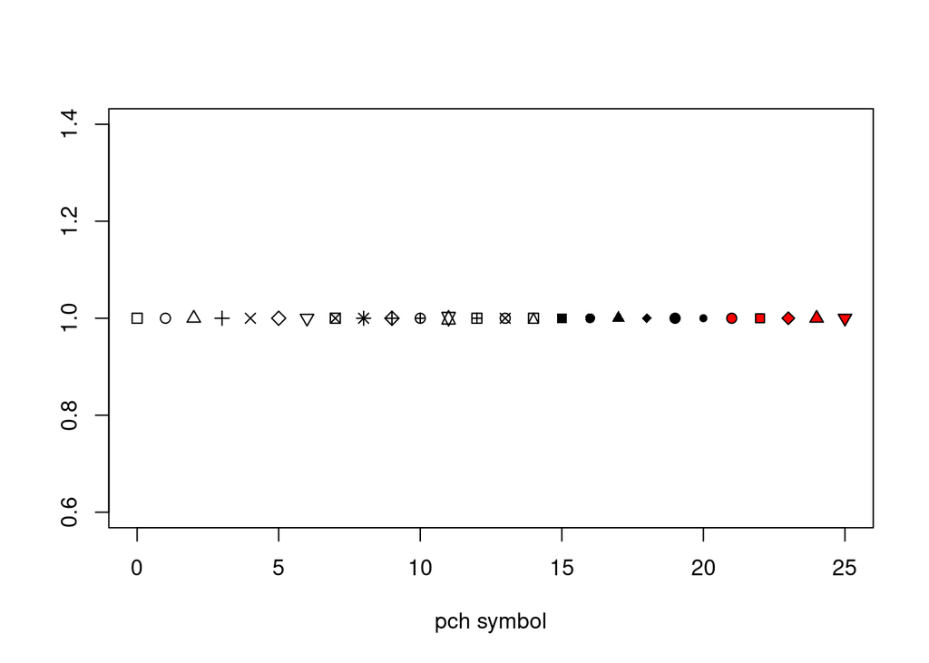

```r
# pch specifies the plot symbol, values 0:25 are valid, here is what
# they look like
plot(0:25, rep(1, 26), pch = 0:25, xlab = "pch symbol", ylab = "", bg = "red")
```

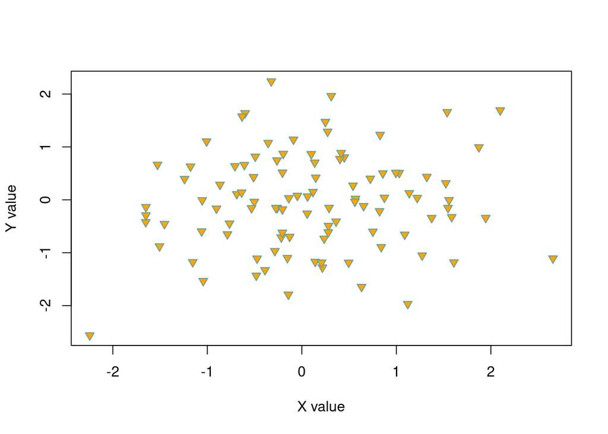

```r
# Here is the first plot again with a different symbol and color
plot(x, y, xlab = "X value", ylab = "Y value", col = "cadetblue", bg = "orange",
    pch = 25)
```

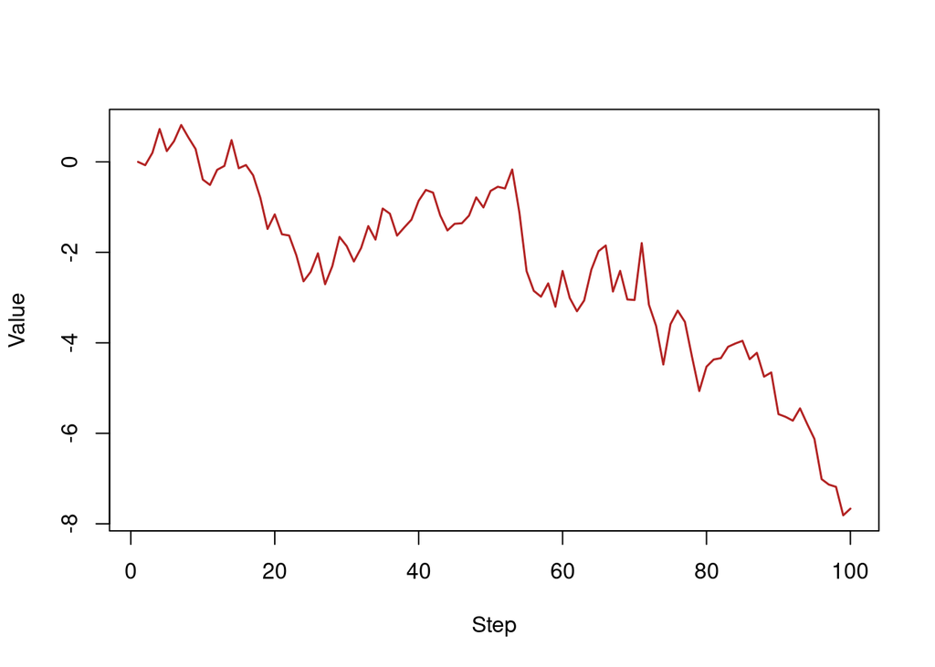

```r
# We can also make line plots, lets generate a random walk to plot as
# a line plot, note type='l'
val <- rep(0, 100)
for (i in 2:100) {
    val[i] <- val[i - 1] + rnorm(1, 0, 0.5)
}
# lwd adjusts the line width, values > 1 make it wider than default
plot(1:100, val, type = "l", xlab = "Step", ylab = "Value", col = "firebrick",
    lwd = 1.5)
```

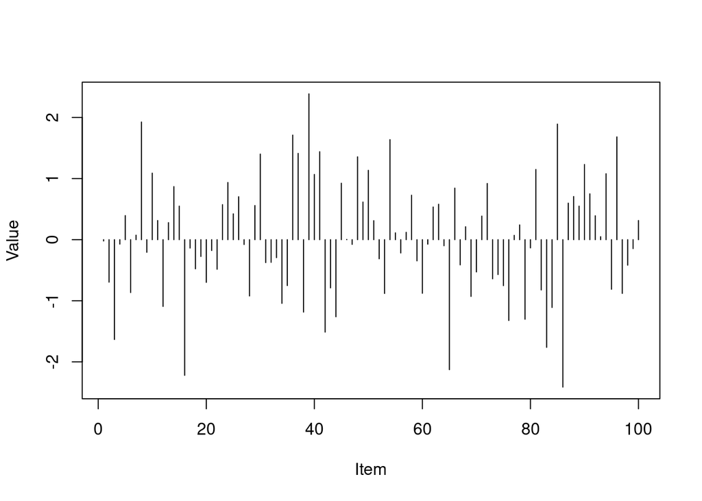

```r
# Finally, we can make histogram or barplot style plot with type='h'
# In some cases hist() or barplot() might be better options
plot(1:100, rnorm(100, 0, 1), type = "h", col = "black", xlab = "Item",
    ylab = "Value")
```

Once you have made a plot, with the `plot` function, you can add things to it. In the examples below, we will see how to add additional points and lines, a title and legend.

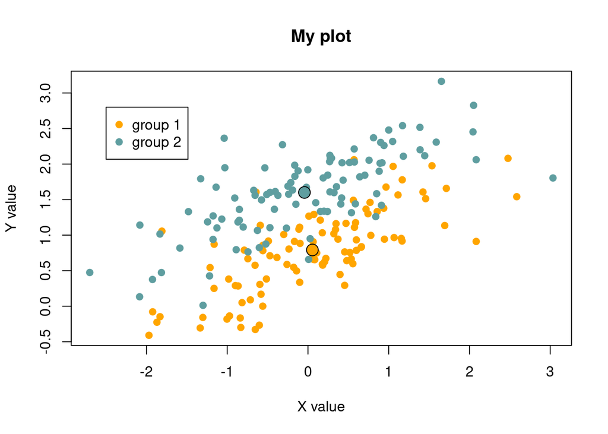

```r
# First lets generate a vector x, which you can think of as a
# covariate in some model
x <- rnorm(200, mean = 0, sd = 1)

# Now lets assume the first 100 values belong to one group, next 100
# to another
grp <- rep(c(1, 2), each = 100)

# Lets assume group has some affect on a response variable as does
# the covariate
y <- grp * 0.8 + x * 0.4 + rnorm(200, 0, 0.4)

# Now we will make a x-y scatterplot and color the points based on
# their group
plot(x, y, col = c("orange", "cadetblue")[grp], pch = 19, xlab = "X value",
    ylab = "Y value")

# Lets add a legend, we first specify x y coords.
legend(-2.5, 2.8, c("group 1", "group 2"), pch = 19, col = c("orange",
    "cadetblue"))
# And a title
title(main = "My plot")

# Last let's add the mean value for x and y for each group
g1mnX <- mean(x[grp == 1])
g1mnY <- mean(y[grp == 1])
g2mnX <- mean(x[grp == 2])
g2mnY <- mean(y[grp == 2])
# Note use of points function to add to plot cex adjusts size
points(g1mnX, g1mnY, pch = 21, cex = 1.8, bg = "orange")
points(g2mnX, g2mnY, pch = 21, cex = 1.8, bg = "cadetblue")
```

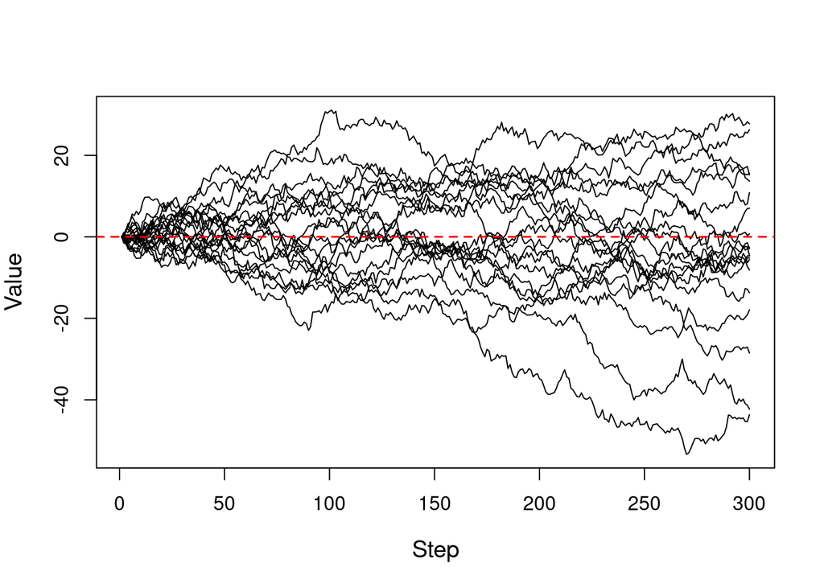

```r
# Now let's plot 20 random walks
val <- matrix(0, nrow = 20, ncol = 300)
for (i in 1:20) {
    # loop over 20 walks loop over steps
    for (j in 2:300) {
        val[i, j] <- val[i, j - 1] + rnorm(1, 0, 1)
    }
}

# Plot first line/walk, make sure y range can accommodate all walks
lb <- min(as.vector(val))
ub <- max(as.vector(val))
# Note use of ylim to define y limits, xlim works similarly cex.lab
# adjust the axis lables
plot(1:300, val[1, ], type = "l", ylim = c(lb, ub), xlab = "Step", ylab = "Value",
    cex.lab = 1.2)
for (i in 2:20) {
    # lines to add lines
    lines(1:300, val[i, ])
}

# We can also add a horizontal line at y=0 This is done with the
# abline function, here h = horiz, v = vert
abline(h = 0, lty = 2, col = "red", lwd = 1.5)  #lty = 1 solid, 2 dash, 3 dot
```

## **Plot layouts**

Many common options for plotting are described on the help page for `par`. This includes options within the plot function and options for laying out plots. Let’s look at options for laying out plots briefly and make a four-panel figure.

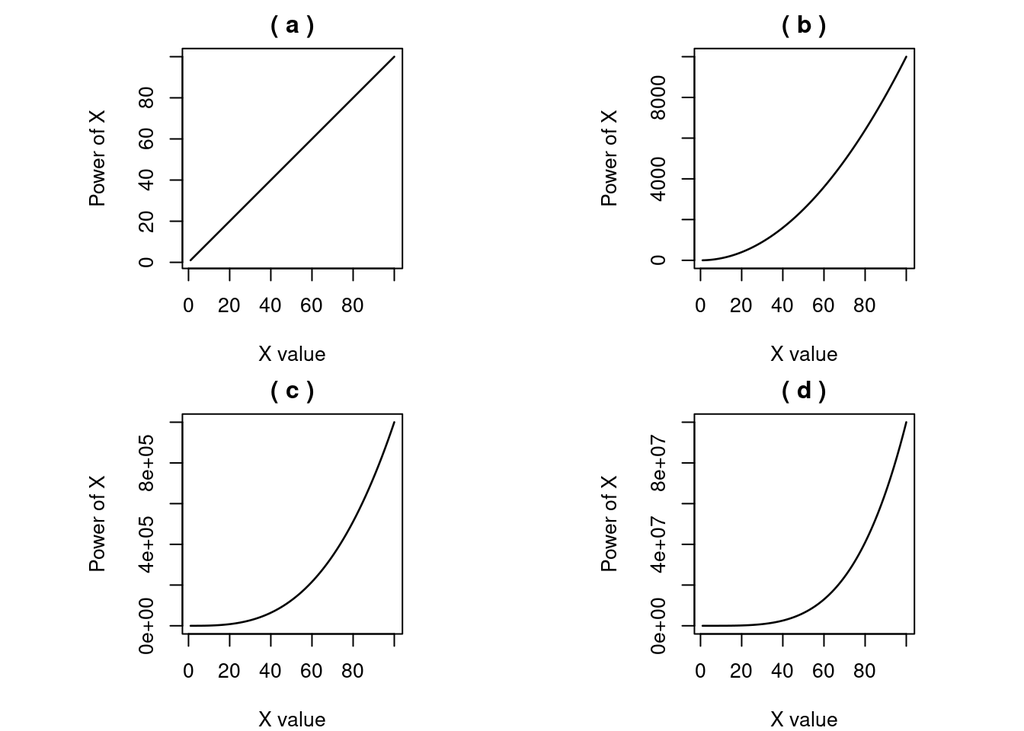

```r
# Here we define a layout for a 2 (row) x 2 (column) plot Fancier
# layouts are possible with the layout function
par(mfrow = c(2, 2))

# Let's make the four plots, each a line plot of x vs x^n where n =
# 1,2,3,4
x <- 1:100
for (i in 1:4) {
    plot(x, x^i, xlab = "X value", ylab = "Power of X", type = "l", lwd = 1.3)
    title(main = paste("(", letters[i], ")"))
}

# Same as before, but force the panels to be squares and adjust
# margins
par(mfrow = c(2, 2))
par(mar = c(4, 4.5, 2, 1.5))  #lower, left, upper, right
par(pty = "s")
x <- 1:100
for (i in 1:4) {
    plot(x, x^i, xlab = "X value", ylab = "Power of X", type = "l", lwd = 1.3)
    title(main = paste("(", letters[i], ")"))
}
```

[output not shown]

## **Testing your knowledge**

Let’s apply what you learned. First, you will need a data set. We can load a data set that is already available in `R` for this. Let’s use data from a plant growth experiment. You can access the data set like this:

```r
data(Loblolly)
Loblolly
```

```
##    height age Seed
## 1    4.51   3  301
## 15  10.89   5  301
## 29  28.72  10  301
## 43  41.74  15  301
## 57  52.70  20  301
## 71  60.92  25  301
## 2    4.55   3  303
## 16  10.92   5  303
## 30  29.07  10  303
## 44  42.83  15  303
## 58  53.88  20  303
## 72  63.39  25  303
## 3    4.79   3  305
## 17  11.37   5  305
```

[output cut: 70 more lines]

The `Loblolly` data frame has 84 rows and 3 columns of records of the growth of Loblolly pine trees.

**Here is your task.** Generate a plot showing the growth of each of trees (defined by seed) over time (defined by age). I suggest using a line plot with one line per tree. Use a different color for each tree and include a legend denoting what color was used for each tree (seed number). You can use `colors()` to generate the full set of `R` colors and then indexes to choose some subset, or `rainbow(14)` to generate 14 colors sampled from across the rainbow.